# Final Project

GuillermoSchneider

2024-05-05

*libraries*

```r
library(tidyverse)
```

```r
library(ggplot2)
#install.packages('cowplot')
library(cowplot)
#install.packages('caret')
library(caret)
#install.packages("rpart.plot")
library(rpart.plot)
```

*My boss said i can use our aggregated data, internal ID’s, first names, no identifying info. same with account and employer info.*

## who our union represents:

**Cleaners, janitors, security guards, ushers, doormen, window cleaners**

## our most notable employers:

**World Trade Center, Empire State Building, Madison Square Garden, Yankee stadium , Barclays Center, Metropolitan opera house, Port Authority, CUNY Graduate Center**

jan 2023 to dec 2023

## steward info, leader points, and purple points, turnout points (CRM-prod)

2023 stewards

**SQL Query (CRMSQL):** `{eval=FALSE, sql connection=CRMSQL} SELECT P.v3personID as 'Member ID', D.divisionName AS 'Division', DI.divisionTypeName AS "Division Type", P.firstName, PSR.personalActivityPoints as 'Activity Points', PSR.totalLeadershipPoints as 'Leader Points', PSR.ADFcardPoints as 'ADF Points', PSR.membershipCardPoints as 'Member Card Points', PSR.turnoutPoints as 'Turnout Points', PSR.rewardType as 'Reward Type', PSR.suggestedRewardLevel as 'Reward', PSR.numofDaysSteward, PSR.numOfDaysOnBrigades, PSR.numOfDaysOnLOA, a.V3accountID as 'Account Id' from personsRoles PR LEFT JOIN persons P on P.v3personID = PR.v3personID LEFT JOIN accounts A on PR.v3accountID = A.v3accountID LEFT JOIN jobs J ON P.primaryJobID = J.jobID LEFT JOIN statuses S on S.statusID = J.statusID LEFT JOIN accounts AC on AC.accountID = J.accountID LEFT JOIN divisions D on AC.divisionID = D.divisionID LEFT JOIN divisionTypes DI ON AC.divisionTypeID = DI.divisionTypeID LEFT JOIN locations L on AC.locationID = L.locationID LEFT JOIN personsStewardRebates PSR on PSR.v3personID = P.v3personID WHERE PR.roleTypeID = 1 AND (PR.statusID = 1 OR PR.dateEnd > '01-01-2023') AND (A.dateStop > '01/01/2023' or A.dateStop is null) AND PSR.rebateYear = 2023 AND D.divisionName NOT LIKE '%615%' GROUP BY P.v3personID, D.divisionName, AC.fieldRepresentative, PSR.rewardType, P.firstName, P.lastName, PSR.personalActivityPoints, PSR.totalLeadershipPoints, PSR.ADFcardPoints, PSR.membershipCardPoints, PSR.turnoutPoints, PSR.rewardType, PSR.suggestedRewardLevel, PSR.numofDaysSteward, PSR.numOfDaysOnBrigades, PSR.numOfDaysOnLOA, L.locationName, a.V3accountID, DI.divisionTypeName, P.homePhone, P.cellPhone, P.email, S.statusName ORDER BY D.DivisionName, AC.fieldRepresentative`

**NY Commercial 2023 Steward Points, their attendance and attendance of people in their building**

```r
StewardPoints <- read.csv("https://raw.githubusercontent.com/GuillermoCharlesSchneider/DATA-607/main/Final%20Project/Purple%20Points%20by%20steward%20(with%20their%20account%20numbers).csv")

#subset just the stewards in the NY Commercial division (no LOA complaints)
StewardPoints <- StewardPoints[which(StewardPoints$Division == 'NY Commercial'),]

StewardPoints$Account.Id <- as.numeric(StewardPoints$Account.Id)
```

## account info, complaints, complaint type? one hot encoding, claim types? (CRM-SQL)

**SQL query (CRMprod):** `{eval=FALSE, sql connection=CRMprod} SELECT a.accountnumber, c.seiu32bj_claimtypename, count(c.seiu32bj_claimtypename) as 'Number of Complaints' FROM filteredseiu32bj_claim c LEFT JOIN filteredIncident i on i.incidentid = c.seiu32bj_complaint LEFT JOIN FilteredAccount a ON i.seiu32bj_account = a.accountid LEFT JOIN Filteredseiu32bj_steward s ON a.accountid = s.seiu32bj_stewardaccountlookup WHERE c.createdon >= '2023-01-01 00:00:00.000' AND c.createdon < '2024-01-01 00:00:00.000' AND a.seiu32bj_districtname = 'New York Metro' AND a.seiu32bj_division = 'NY Commercial' AND i.customeridname != 'Test Member' GROUP BY a.accountnumber, c.seiu32bj_claimtypename ORDER by a.accountnumber DESC`

**NY Commercial Total Complaints per account in 2023:**

```r
TotalComplaints <- read.csv("https://raw.githubusercontent.com/GuillermoCharlesSchneider/DATA-607/main/Final%20Project/Total%20Complaints%20Per%20Account.csv")

names(TotalComplaints)[1] <- "Account.Id"

#account id
TotalComplaints$Account.Id <- as.numeric(TotalComplaints$Account.Id)

#remove complaints from EVENT, NULL, and NA job type workers
#TotalComplaints <- TotalComplaints[ -c(5,6,7) ]
```

**NY Commercial Count of Complaint types per account in 2023:**

```r
ComplaintTypes <- read.csv("https://raw.githubusercontent.com/GuillermoCharlesSchneider/DATA-607/main/Final%20Project/Complaint%20Types%20Per%20account%20(convert%20to%20one%20hot).csv")

ComplaintTypes <- ComplaintTypes[which(ComplaintTypes$seiu32bj_claimtypename != 'Leave of Absence'),]
```

**NY Commercial Count of Members per account in 2023:** *i filtered out the recent 2024 hires, and made sure to include members who left in 2024, but were on the roster in 2023, i think ultimately the number is very close to just pulling the current 2024 roster today, due to most places total job count staying relatively stable*

**SQL Query (CRMprod)** `{eval=FALSE, sql connection=} SELECT DISTINCT a.V3accountID as 'Account.Id', count(a.V3accountID) as 'Members' FROM [dbo].[jobs] j LEFT JOIN accounts a on j.accountID = a.accountID WHERE a.divisionID = 9 AND j.dateHired < '2024-01-01 00:00:00.000' AND (j.statusID = 1 or (j.dateTerminated > '2024-01-01 00:00:00.000')) AND (A.dateStop > '01/01/2023' or A.dateStop is null) GROUP by a.V3accountID ORDER by count(a.V3accountID) DESC`

**MemberCountPerAccount**

```r
MemberCountPerAccount <- read.csv("https://raw.githubusercontent.com/GuillermoCharlesSchneider/DATA-607/main/Final%20Project/MembersPerAccount.csv")
```

**Cleaning:**

```r
#join in the total complaints for that account
MERGED <- StewardPoints %>% left_join(TotalComplaints)
MERGED <- MERGED %>% left_join(MemberCountPerAccount)
# NA's to 0
MERGED$FTComplaints[is.na(MERGED$FTComplaints)] <- 0
MERGED$PTComplaints[is.na(MERGED$PTComplaints)] <- 0
MERGED$TotalComplaints[is.na(MERGED$TotalComplaints)] <- 0
MERGED$FTAverageMembers[is.na(MERGED$FTAverageMembers)] <- 0
MERGED$PTAverageMembers[is.na(MERGED$PTAverageMembers)] <- 0
MERGED$FTMembers[is.na(MERGED$PTMembers)] <- 0
MERGED$PTMembers[is.na(MERGED$PTMembers)] <- 0
MERGED$TotalAverageMembers[is.na(MERGED$TotalAverageMembers)] <- 0
MERGED$TotalMembers[is.na(MERGED$TotalMembers)] <- 0

# removing the acccounts with 0 members. my guess is most of these are probably flipped accounts, another company took them over mid 2023, those members still exist but in a new account for a new employer, same steward
MERGED <- MERGED[which(MERGED$TotalMembers != 0),]

#keep just the year-long stewards
MERGED <- MERGED[which(MERGED$numofDaysSteward == 365),]

#removed the EVT workers. only 4 accounts, huge amounts of rotating temp workers, lots of complaints, no long relationship w/ their steward
#changed to removing the Event workers in the SQL query
#MERGED <- MERGED[which(MERGED$EVTMembers == 0),]

#add a new column of complaint rate, complaints / total members
#MERGED <- MERGED
MERGED$ComplaintRate <- MERGED$TotalComplaints / MERGED$TotalAverageMembers * 100
```

**Total AVERAGE Member count variable:** This is to account for turnover through the year. Take all the members who worked at location in 2023, Sum the Number of days worked by each employee, and divide by 365. This gives you a approximate “average roster size” for throughout all of 2023. Each member needs to be included, because each member has a opportunity to file a complaint while they work and are represented by the union, regardless of how short their work length was

**OVERALL leadership points: Combining stewards by account. I added together the stewards for each account. bigger accounts often have multiple stewards.**

```r
GroupedStewards <- MERGED %>% group_by(Account.Id, FTComplaints,PTComplaints,TotalComplaints, FTAverageMembers, PTAverageMembers,TotalAverageMembers, FTMembers, PTMembers,TotalMembers,ComplaintRate) %>% summarise(totalActivityPoints = sum(Activity.Points),totalTurnoutPoints = sum(Turnout.Points) ,.groups = 'drop')

GroupedStewards
```

```
## # A tibble: 349 × 13
##    Account.Id FTComplaints PTComplaints TotalComplaints FTAverageMembers
##         <dbl>        <dbl>        <dbl>           <dbl>            <dbl>
##  1       9332            0            0               0             5.25
##  2       9362            0            0               0             3
##  3      13482            1            0               1             1.19
##  4      13483            0            0               0             8.33
##  5      13502            0            0               0             2.16
##  6      13518            0            0               0             3
##  7      13541            0            0               0             4.81
##  8      13803            5            0               5             9.17
##  9      13829            0            0               0             3
## 10      14093            0            0               0             2
## # ℹ 339 more rows
## # ℹ 8 more variables: PTAverageMembers <dbl>, TotalAverageMembers <dbl>,
## #   FTMembers <dbl>, PTMembers <dbl>, TotalMembers <dbl>, ComplaintRate <dbl>,
## #   totalActivityPoints <int>, totalTurnoutPoints <int>
```

## Graphs:

**There are 4 big accounts that are outside 100 members, but most of the accounts fall between this range i set up to easier visualize**

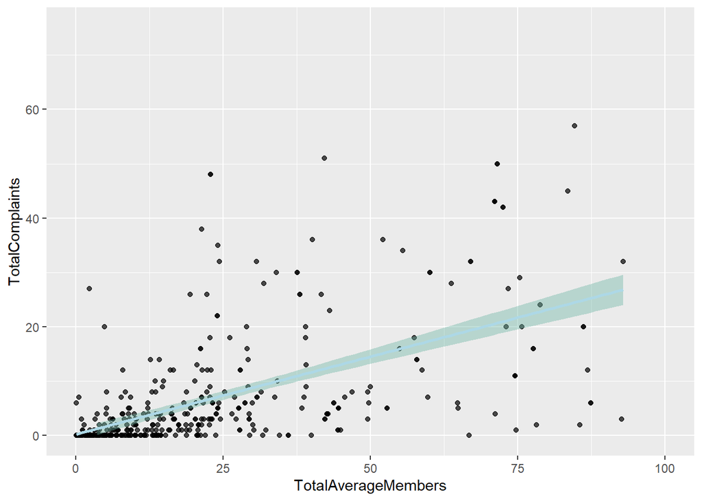

```r
ggplot(MERGED, aes(x=TotalAverageMembers, y=TotalComplaints)) +
    geom_point(alpha=0.7)+
  xlim(0,100)+
  ylim(0,75)+
  geom_smooth(method=lm, color="lightblue", fill="#69b3a2", se=TRUE)
```

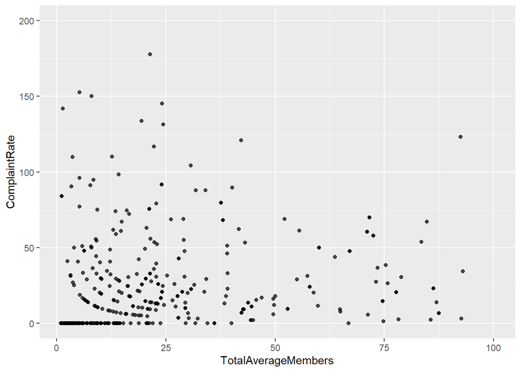

```r
ggplot(MERGED, aes(x=TotalAverageMembers, y=ComplaintRate)) +
    geom_point(alpha=0.7)+
  ylim(0,200)+
  xlim(1,100)
```

```r
  geom_smooth(method=lm , color="lightblue", fill="#69b3a2", se=TRUE)
```

[output not shown]

[output cut: 9 more lines]

[output not shown]

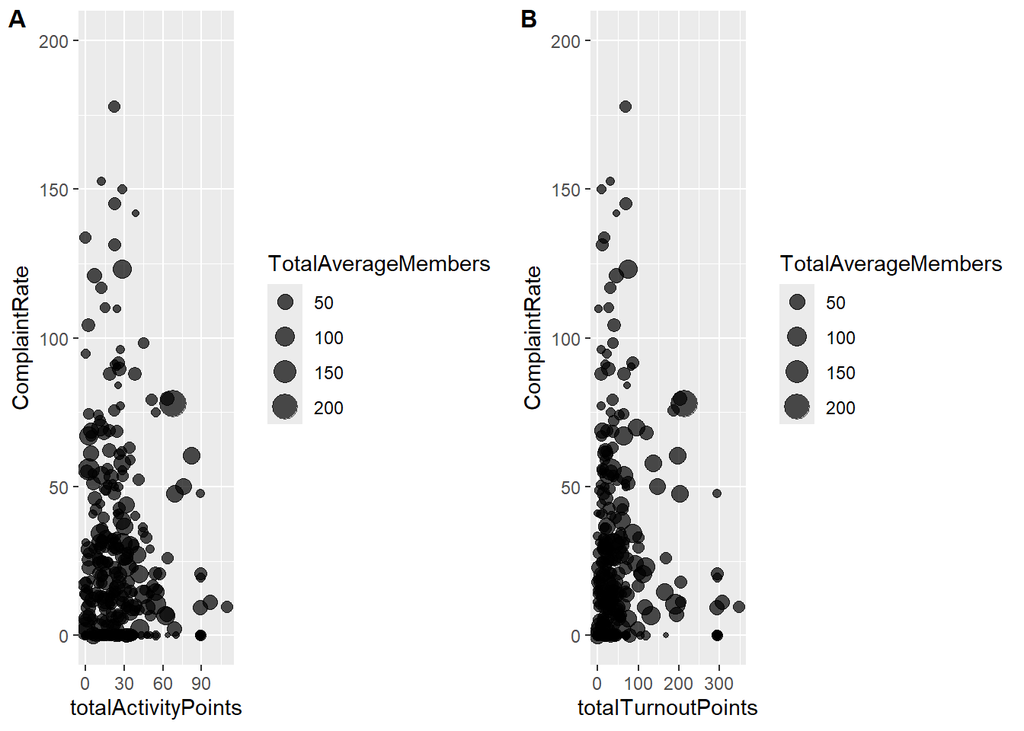

```r
CL1 <- ggplot(GroupedStewards, aes(x=totalActivityPoints, y=ComplaintRate, size = TotalAverageMembers)) +
    geom_point(alpha=0.7) +
  ylim(0,200)

CL2 <- ggplot(GroupedStewards, aes(x=totalTurnoutPoints, y=ComplaintRate, size = TotalAverageMembers)) +
    geom_point(alpha=0.7)+
  ylim(0,200)

plot_grid(CL1, CL2, labels = c('A', 'B'), label_size = 12)
```

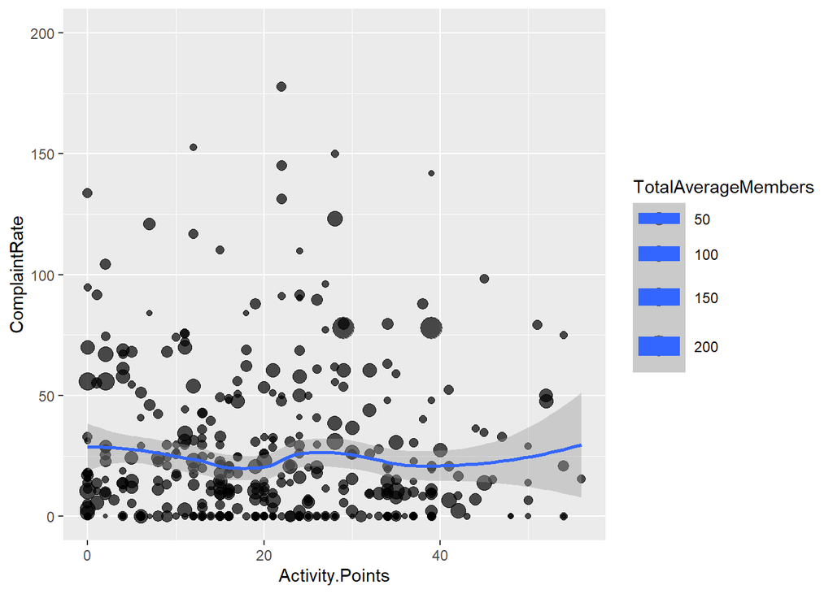

```r
ggplot(MERGED, aes(x=Activity.Points, y=ComplaintRate, size =TotalAverageMembers)) +
    geom_point(alpha=0.7)+
  ylim(0,200)+
  geom_smooth()
```

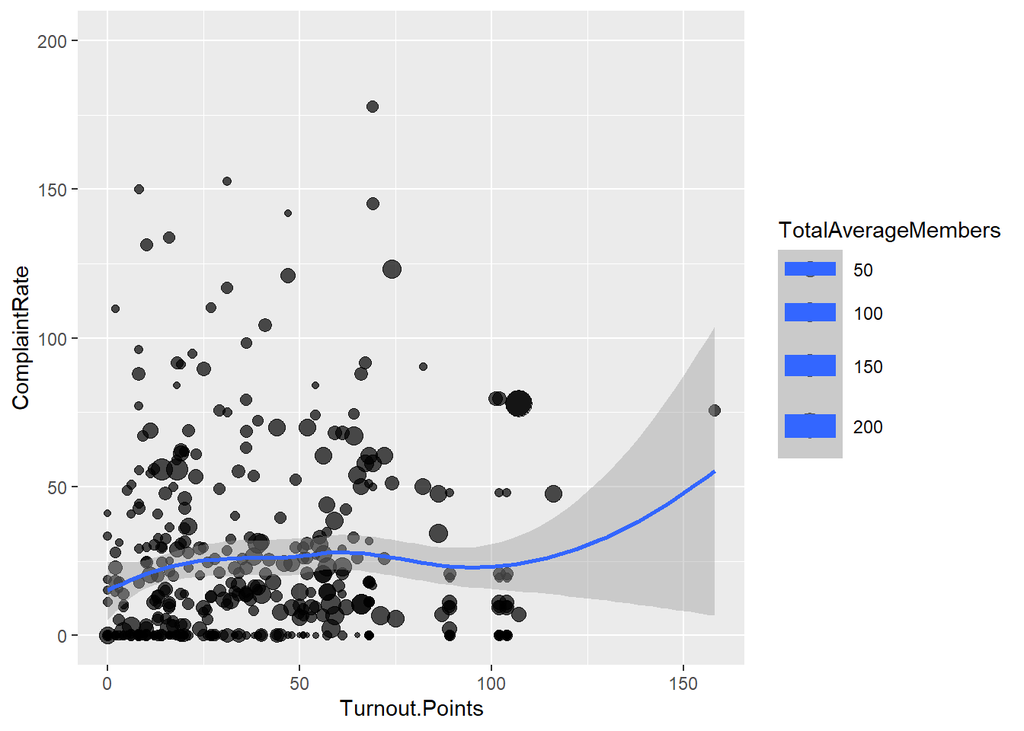

```r
ggplot(MERGED, aes(x=Turnout.Points, y=ComplaintRate, size=TotalAverageMembers)) +
    geom_point(alpha=0.7)+
  ylim(0,200)+
  geom_smooth()
```

## machine learning – decision tree

*https://www.modernstatisticswithr.com/mlchapter.html#mlmethods*

```r
tc <- trainControl(method = "LOOCV")

m <- train(ComplaintRate ~ Activity.Points + Turnout.Points + FTAverageMembers + PTAverageMembers + TotalAverageMembers,
           data = MERGED,
           trControl = tc,
           method = "rpart",
           tuneGrid = expand.grid(cp = 0))

m2 <- train(ComplaintRate ~ totalActivityPoints + totalTurnoutPoints + FTAverageMembers + PTAverageMembers + TotalAverageMembers,
           data = GroupedStewards,
           trControl = tc,
           method = "rpart",
           tuneGrid = expand.grid(cp = 0))
```

```r
m
```

```
## CART
##
## 427 samples
##   5 predictor
##
## No pre-processing
## Resampling: Leave-One-Out Cross-Validation
## Summary of sample sizes: 426, 426, 426, 426, 426, 426, ...
## Resampling results:
##
##   RMSE      Rsquared     MAE
##   323.0354  0.001064295  64.94875
##
## Tuning parameter 'cp' was held constant at a value of 0
```

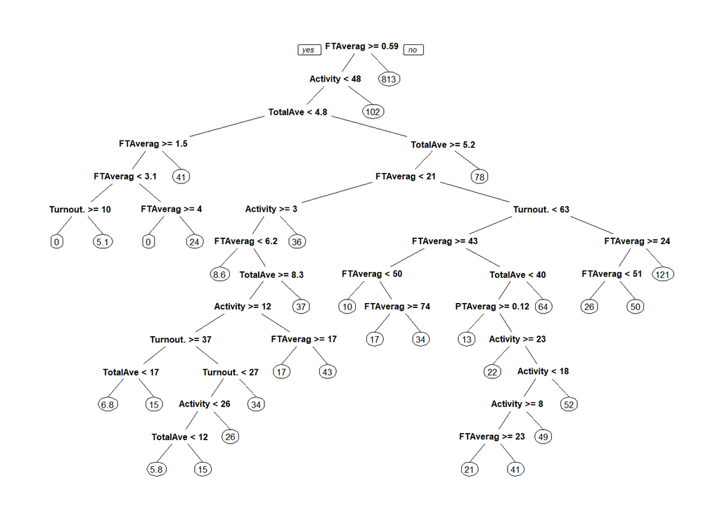

```r
prp(m$finalModel)
```

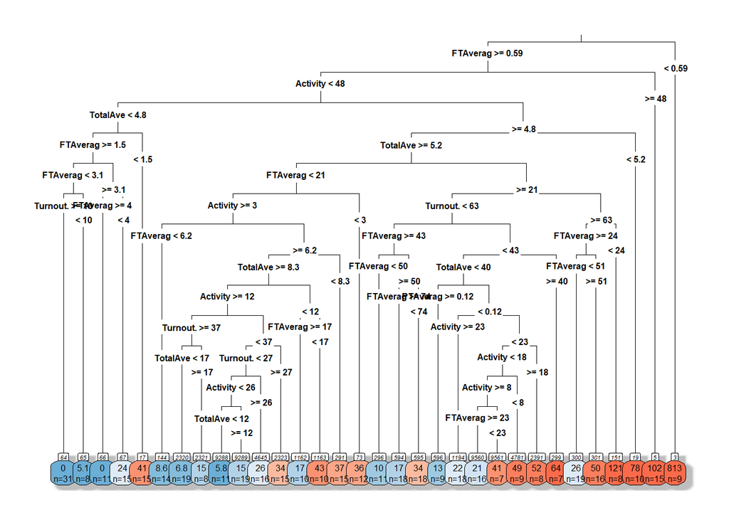

```r
prp(m$finalModel,
    box.palette = "BuRd",
    shadow.col = "gray",
    nn = TRUE,
    type =3,
    extra = 1,
    cex = 0.5,
    compress=TRUE,
    fallen.leaves = TRUE)
```

**Trying instead with grouped stewards**

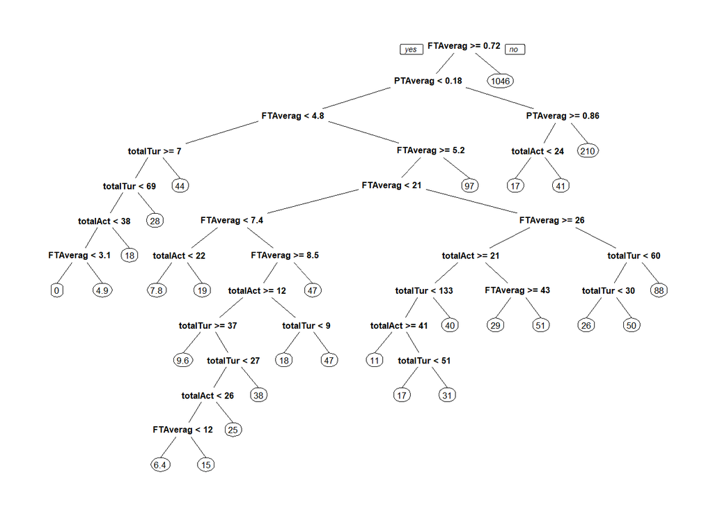

```r
prp(m2$finalModel)
```

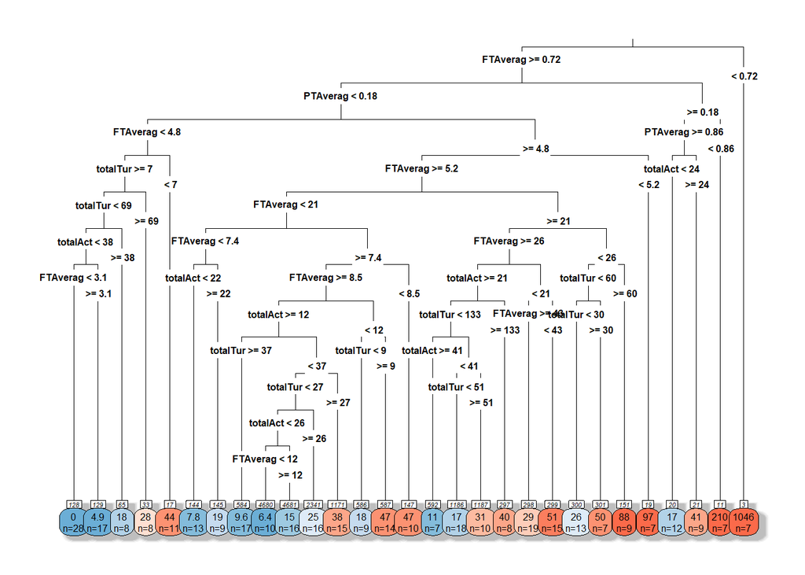

```r
prp(m2$finalModel,
    box.palette = "BuRd",
    shadow.col = "gray",
    nn = TRUE,
    type =3,
    extra = 1,
    cex = 0.5,
    compress=TRUE,
    fallen.leaves = TRUE)
```

## ACTUAL vs PREDICTED

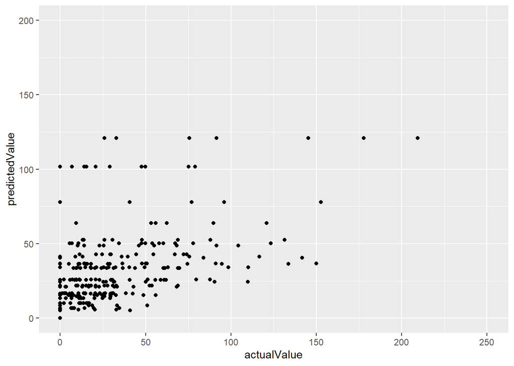

```r
actualAndPredictedData = data.frame(Account.Id = MERGED$Account.Id, StewardName = MERGED$firstName, Steward.Id = MERGED$Member.ID, actualValue = MERGED$ComplaintRate,
                                    predictedValue = predict(m,MERGED))

ggplot(actualAndPredictedData,aes(x = actualValue, y = predictedValue)) +
ylim(0,200)+
xlim(0,250)+
geom_point()
```

```r
#write.csv(actualAndPredictedData, "actualAndPredictedData.csv")
```